# Configure GitHub.com access through OAuth

- 3min
- |
- HCP Terraform
- Terraform

HCP Terraform is more powerful when you integrate it with your version control system (VCS). There are three different ways to connect GitHub.com to HCP Terraform.

1. Our [configuration-free GitHub App](https://developer.hashicorp.com/terraform/cloud-docs/vcs/github-app) — we recommend this method for beginning users on HCP Terraform.
2. Configuring GitHub.com access to HCP Terraform through OAuth connection — use this method to manage your HCP Terraform workspaces via the [TFE Provider](https://registry.terraform.io/providers/hashicorp/tfe/latest/docs) or [HCP Terraform API](https://developer.hashicorp.com/terraform/cloud-docs/api-docs).
3. Skip the OAuth configuration process and authenticate with a personal access token. This requires using HCP Terraform's API. For details, see the [OAuth Clients API](https://developer.hashicorp.com/terraform/cloud-docs/api-docs/oauth-clients) page.

Tip

There are separate instructions to connect HCP Terraform to [GitHub Enterprise](https://developer.hashicorp.com/terraform/cloud-docs/vcs/github-enterprise) and [other supported VCS providers](https://developer.hashicorp.com/terraform/cloud-docs/vcs).

In this tutorial, you will set up GitHub.com OAuth access to HCP Terraform by completing the following three steps.

1. On HCP Terraform, add a new VCS Provider
2. On GitHub, create a new OAuth application
3. On HCP Terraform, set up your provider

## Prerequisites

For this tutorial, you will need:

1. an [HCP Terraform](https://app.terraform.io/session) account with [permission to manage VCS settings](https://developer.hashicorp.com/terraform/cloud-docs/users-teams-organizations/permissions#manage-vcs-settings) for the organization
2. a [GitHub](https://github.com/) account

## On HCP Terraform, add a new VCS Provider

Open [HCP Terraform](https://app.terraform.io/session) in your browser and navigate to your organization settings. Then, select **Version Control | Providers** from the left navigation.

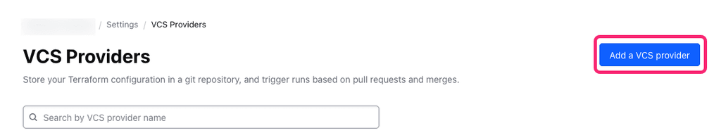

Click the **Add a VCS Provider** button. Select **GitHub** then **GitHub.com (Custom)** from the dropdown.

[figure not shown]

The next page includes instructions to set up your provider by registering a new OAuth application.

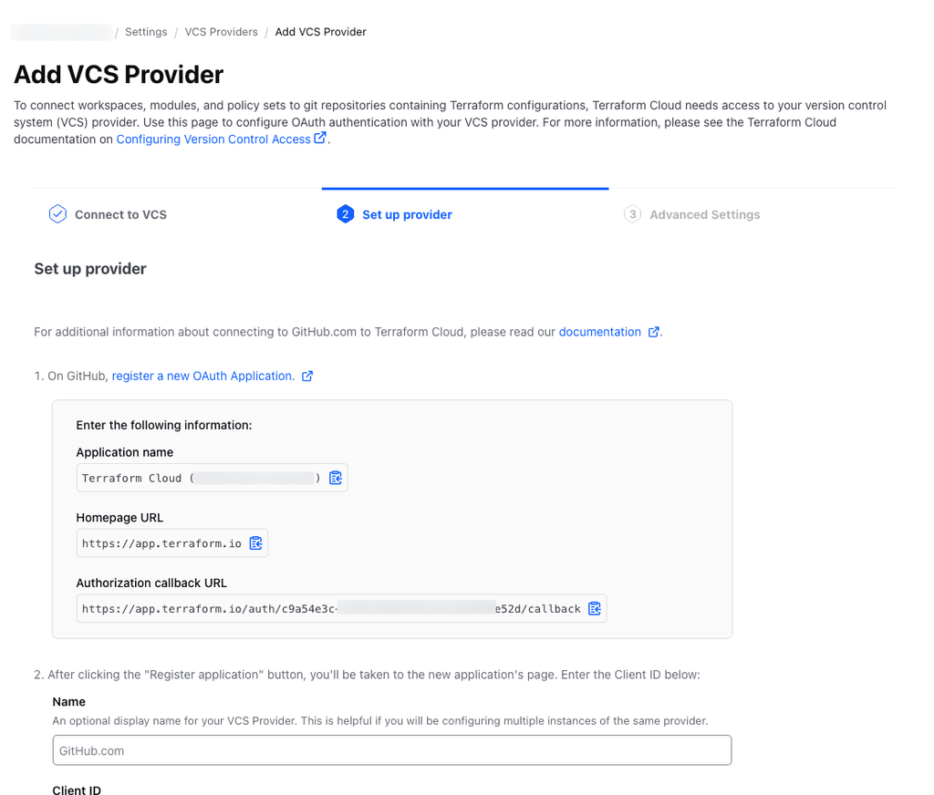

## On GitHub, create a new OAuth application

In a new browser tab, open GitHub's [Register a New OAuth Application](https://github.com/settings/applications/new) page.

Fill out the text fields with the values from the HCP Terraform "Add VCS Provider" page. Then, click "Register application".

[figure not shown]

GitHub should return a **Client ID** and **Client Secret**. You will use these values to set up your HCP Terraform VCS provider.

[figure not shown]

## On HCP Terraform, set up your provider

Navigate to the tab you used to create a new VCS provider.

Enter the **Client ID** and **Client Secret** from the previous step to finish setting up your VCS provider. Click "Connect and continue".

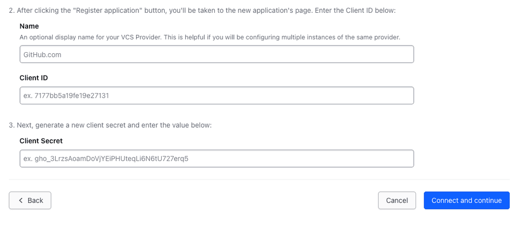

This takes you to a page on GitHub.com, asking whether you want to authorize the app. Authorize the HCP Terraform app against GitHub by clicking the green "Authorize <GITHUB_USER>" button.

Your browser will return to HCP Terraform. On the Advanced Settings step, you can optionally restrict this VCS provider to selected projects, configure policy sets, modules, and an SSH keypair.

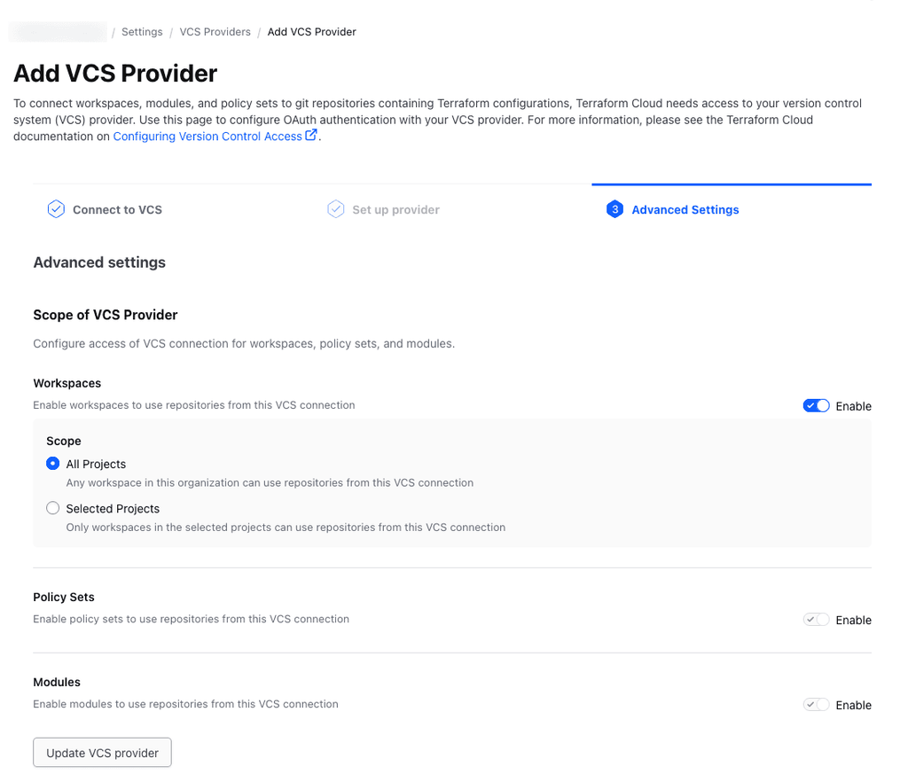

## Next steps

You have successfully configured your HCP Terraform organization to access GitHub.com through OAuth connection.

If you had trouble setting up GitHub OAuth, in-depth instructions can be found on the [Configuring GitHub.com Access (OAuth)](https://developer.hashicorp.com/terraform/cloud-docs/vcs/github) documentation page.

© 2026 HashiCorp  
Licensed under the MPL 2.0 License.  
https://developer.hashicorp.com/terraform/tutorials/automation/github-oauth